# Part 2: College Dropout Modeling and Prediction

The Kumar Kids

2023-04-13

# Introduction

### Background of the Data

In this report, we will be analyzing a data set of students who have either graduated, dropped out, or are still enrolled from a four year undergraduate degree. This data, which is amalgamated from several different sources, includes information on demographic, socioeconomic, macroeconomic, and academic factors for these students. The success of students in higher education is vital to the overall productivity of an economy, as human capital is a huge driver of growth.

### Structure of the Data

This dataset has 35 overall columns, with 1 being our target variable and the others being characteristics of both the students and their environment. We have demographic information like marital status, gender, and age of the students. We also have financial information of the students like whether they are a debtor, have their tuition fees up to date, or are on a scholarship. There are also academic characteristics of these students such as their approved credits, course of study, or whether they have educational special needs. Lastly, there are macroeconomic indicators as well as they are strongly correlated with trends in education.

Our target variable for training the model will be whether or not the students graduated, and we will then use the models we built on the students that are currently enrolled to predict whether they have a high likelihood of dropping out. When we do our analysis, the column “TargetGraduate” indicates whether that student graduated with a value of “1” for graudate and “0” for non graduate.

### Use Case

We will be posing as a consulting group hired on by the board of directors of the Polytechnic Institute Of Portalegre. We were brought on in order to figure out how we can create a lower dropout rate than the average in the United States. Reports indicate that around 40% of undergraduates do not complete their degree program. In our data it appears that, among the combined students that have either dropped out or graduated, around 40% of the students also did not graduate. We want to figure out if we can give the Institute an edge in terms of putting through high quality graduates.

Knowing the characteristics of students who are likely to drop out, the academic advisors could further evaluate the situation of these “likely-to-dropout” students case by case, and reach out to offer academic planning/support to reduce their likelihood of dropping out. With the number of enrolled students who would likely drop out, the finance office can estimate the amount of tuition the university would lose per year with this number. The university admission office could also use this number to decide the number of transfer students we can allow next year to fill the gap.

# Building Baseline Model

In our analysis, we will be utilizing the steps laid out to us in TO 628 by Dr. Kumar. The steps are as follows: data loading, data cleaning, splitting training/testing data, followed by predictive model training and model evaluation. After that, we see if we can iterate and improve! The models that we will be using to analyze our college students are:

- Logistic Regression
- Artificial Neural Network
- Decision Tree
- Random Forest Model

## Testing and Training Sets

```r
#Loading in cleaned data set from Part 1
drop_norm <- read.csv("cleaned_nonenrolls.csv")

#Setting seed for ease of replication
set.seed(12345)
trainrows <- sample(nrow(drop_norm), 0.8*nrow(drop_norm))

#Training and testing sets with full columns
droptrain <- drop_norm[trainrows, ]
droptest <- drop_norm[-trainrows, ]

#Sets without Y variable
knn_train <- drop_norm[trainrows, -match("TargetGraduate", names(drop_norm))]
knn_test <- drop_norm[-trainrows, -match("TargetGraduate", names(drop_norm))]

#Sets with just Y variable
train_labels <- drop_norm[trainrows, "TargetGraduate"]
test_labels <- drop_norm[-trainrows, "TargetGraduate"]
```

The target variable `TargetGraduate` is a dummy variable with two values: 0 and 1.

- 0: this student has dropped out from the university
- 1: this student successfully graduated from the university

## Helper Functions

These two functions will aid the model evaluation step in later analysis.

```r
get_sensitivity <- function(cm) { # a function that returns sensitivity from confusion matrix
  tp <- cm$table[2, 2]
  tn <- cm$table[1, 1]
  fp <- cm$table[2, 1]
  fn <- cm$table[1, 2]
  sens <- tp / (tp + fn)
  return(sens)
}

get_specificity <- function(cm) { # a function that returns specificity from confusion matrix
  tp <- cm$table[2, 2]
  tn <- cm$table[1, 1]
  fp <- cm$table[2, 1]
  fn <- cm$table[1, 2]
  spec <- tn / (tn + fp)
  return(spec)
}
```

## Logistic Model Training

```r
logmod <- glm(TargetGraduate ~., data = droptrain, family = "binomial")
```

## Logistic Model Evaluation

```r
library(caret)
log_pred <- predict(logmod, droptest)
pblog <- ifelse(log_pred >= 0.5, 1, 0)
cm <- confusionMatrix(as.factor(pblog), as.factor(droptest$TargetGraduate), positive = "1")
cm
```

```
## Confusion Matrix and Statistics
##
##           Reference
## Prediction   0   1
##          0 237  48
##          1  40 401
##
##                Accuracy : 0.8788
##                  95% CI : (0.8528, 0.9016)
##     No Information Rate : 0.6185
##     P-Value [Acc > NIR] : <2e-16
##
##                   Kappa : 0.7446
##
##  Mcnemar's Test P-Value : 0.4555
##
##             Sensitivity : 0.8931
##             Specificity : 0.8556
##          Pos Pred Value : 0.9093
##          Neg Pred Value : 0.8316
##              Prevalence : 0.6185
##          Detection Rate : 0.5523
##    Detection Prevalence : 0.6074
##       Balanced Accuracy : 0.8743
##
##        'Positive' Class : 1
##
```

```r
log_kappa <- cm$overall['Kappa']
log_accuracy <- cm$overall['Accuracy']
log_spec <- get_specificity(cm)
```

Logistic model performance

- Kappa: 0.7445726
- Accuracy: 0.8787879

## ANN Model Training

We are building a Neural Network with 1 hidden layer.

```r
library(neuralnet)
model_ann <- neuralnet(TargetGraduate ~ ., data = droptrain, hidden = 1)
```

## ANN Model Evaluation

```r
ann_pred <- predict(model_ann, droptest)
predbin_ann <- ifelse(ann_pred >= 0.5, 1, 0)
cm <- confusionMatrix(as.factor(predbin_ann), as.factor(droptest$TargetGraduate), positive = "1")
cm
```

```
## Confusion Matrix and Statistics
##
##           Reference
## Prediction   0   1
##          0 235  37
##          1  42 412
##
##                Accuracy : 0.8912
##                  95% CI : (0.8662, 0.9129)
##     No Information Rate : 0.6185
##     P-Value [Acc > NIR] : <2e-16
##
##                   Kappa : 0.7686
##
##  Mcnemar's Test P-Value : 0.6527
##
##             Sensitivity : 0.9176
##             Specificity : 0.8484
##          Pos Pred Value : 0.9075
##          Neg Pred Value : 0.8640
##              Prevalence : 0.6185
##          Detection Rate : 0.5675
##    Detection Prevalence : 0.6253
##       Balanced Accuracy : 0.8830
##
##        'Positive' Class : 1
##
```

```r
ann_accuracy <- cm$overall['Accuracy']
ann_kappa <- cm$overall['Kappa']
ann_spec <- get_specificity(cm)
```

2-Layer Neural Network model performance

- Kappa: 0.7686275
- Accuracy: 0.8911846

## Decision Tree Model Training

```r
library(C50)

droptree <- C5.0(as.factor(TargetGraduate) ~., data=droptrain)
```

## Decision Tree Model Evaluation

```r
tree_pred <- predict(droptree, droptest)
cm <- confusionMatrix(as.factor(tree_pred), as.factor(droptest$TargetGraduate), positive = "1")
cm
```

```
## Confusion Matrix and Statistics
##
##           Reference
## Prediction   0   1
##          0 227  22
##          1  50 427
##
##                Accuracy : 0.9008
##                  95% CI : (0.8767, 0.9216)
##     No Information Rate : 0.6185
##     P-Value [Acc > NIR] : < 2.2e-16
##
##                   Kappa : 0.7857
##
##  Mcnemar's Test P-Value : 0.001463
##
##             Sensitivity : 0.9510
##             Specificity : 0.8195
##          Pos Pred Value : 0.8952
##          Neg Pred Value : 0.9116
##              Prevalence : 0.6185
##          Detection Rate : 0.5882
##    Detection Prevalence : 0.6570
##       Balanced Accuracy : 0.8852
##
##        'Positive' Class : 1
##
```

```r
dt_accuracy <- cm$overall['Accuracy']
dt_kappa <- cm$overall['Kappa']
dt_spec <- get_specificity(cm)
```

Decision Tree model performance

- Kappa: 0.785709
- Accuracy: 0.9008264

## Random Forest Model Training

```r
library(randomForest)
forestmodel <- randomForest(as.factor(TargetGraduate) ~., data = droptrain)
```

## Random Forest Model Evaluation

```r
forest_pred <- predict(forestmodel, droptest)

cm <- confusionMatrix(as.factor(forest_pred), as.factor(droptest$TargetGraduate), positive = "1")
cm
```

```
## Confusion Matrix and Statistics
##
##           Reference
## Prediction   0   1
##          0 229  25
##          1  48 424
##
##                Accuracy : 0.8994
##                  95% CI : (0.8752, 0.9204)
##     No Information Rate : 0.6185
##     P-Value [Acc > NIR] : < 2e-16
##
##                   Kappa : 0.7835
##
##  Mcnemar's Test P-Value : 0.01003
##
##             Sensitivity : 0.9443
##             Specificity : 0.8267
##          Pos Pred Value : 0.8983
##          Neg Pred Value : 0.9016
##              Prevalence : 0.6185
##          Detection Rate : 0.5840
##    Detection Prevalence : 0.6501
##       Balanced Accuracy : 0.8855
##
##        'Positive' Class : 1
##
```

```r
rf_accuracy <- cm$overall['Accuracy']
rf_kappa <- cm$overall['Kappa']
rf_spec <- get_specificity(cm)
```

Random Forest model performance

- Kappa: 0.7834961
- Accuracy: 0.899449

## Initial Model Performance Review

So far, our most accurate model in predicting college dropouts has been our Decision Tree model. It has the highest Kappa at 0.79, and the highest accuracy at 90.08%.

It is worthy to note that the accuracy score might be misleading at times. To identify the most importance statistic metric, we need to review the goal of our analysis. For college dropout prediction, we not only want the model to accurately predict who will dropped out and who will not, but also hope the model to lower the likelihood of falsely predicting those who will drop out.

Our main audience, the University Board, would like to correctly identify those who would be likely to drop out so they could take mitigation measures to prevent such result by offering various academic support to those students. In statistical terms, a low False Positive (students who were predicted to graduate but dropped out in reality, FP in short) in is more meaningful than a high accuracy. So our first priority is to lower FP, and then pursue a high Kappa and accuracy score. Since we do not know the relative cost of reaching out to students and offer academic resources/support, we assume that the university would tolerate a moderate False Negative (students who graduated successfully but were predicted to drop out, FN in short).

The reasoning above points out to two statistical metrics that we should pay attention to:

- sensitivity (TP / TP + FN): the percentage of truly graduated students we can predict out of all graduated students in the past
- specificity (TN / TN + FP): the percentage of truly dropped out students we successfully predict out of all drop-outs in the past

In particular, we would love to prioritize a low FP, so a high specificity is what we should prioritize.

# Building Improved Models

## Testing Improved Logistic Model

Improvements to our logistic regression model predictions actually don’t even need to be made to the model itself. All we have to do is increase the prediction threshold for whether or not a student will graduate, and the model will predict less students overall graduating.

```r
#Increasing threshold
pblog_impr <- ifelse(log_pred >= 0.8, 1, 0)
cm <- confusionMatrix(as.factor(pblog_impr), as.factor(droptest$Target), positive = "1")
cm
```

```
## Confusion Matrix and Statistics
##
##           Reference
## Prediction   0   1
##          0 243  58
##          1  34 391
##
##                Accuracy : 0.8733
##                  95% CI : (0.8469, 0.8966)
##     No Information Rate : 0.6185
##     P-Value [Acc > NIR] : < 2e-16
##
##                   Kappa : 0.7359
##
##  Mcnemar's Test P-Value : 0.01649
##
##             Sensitivity : 0.8708
##             Specificity : 0.8773
##          Pos Pred Value : 0.9200
##          Neg Pred Value : 0.8073
##              Prevalence : 0.6185
##          Detection Rate : 0.5386
##    Detection Prevalence : 0.5854
##       Balanced Accuracy : 0.8740
##
##        'Positive' Class : 1
##
```

```r
log_impr_accuracy <- cm$overall['Accuracy']
log_impr_kappa <- cm$overall['Kappa']
log_impr_spec <- get_specificity(cm)
```

Improved Logistic Model Performance:

Although we lose some accuracy (baseline has 0.8787879), we have a specificity score 0.8772563 that is better than 0.8555957 from the Baseline Logistic Model.

## Improved ANN Model Evaluation

Much like our Logistic Model, we do not actually have to create a new neural network in order to improve the ability of our model to catch false positives. All we have to do is increase the prediction threshold.

```r
predbin_ann_impr <- ifelse(ann_pred >= .9483, 1, 0)
cm <- confusionMatrix(as.factor(predbin_ann_impr), as.factor(droptest$TargetGraduate), positive = "1")
cm
```

```
## Confusion Matrix and Statistics
##
##           Reference
## Prediction   0   1
##          0 241  60
##          1  36 389
##
##                Accuracy : 0.8678
##                  95% CI : (0.8409, 0.8916)
##     No Information Rate : 0.6185
##     P-Value [Acc > NIR] : <2e-16
##
##                   Kappa : 0.7244
##
##  Mcnemar's Test P-Value : 0.0189
##
##             Sensitivity : 0.8664
##             Specificity : 0.8700
##          Pos Pred Value : 0.9153
##          Neg Pred Value : 0.8007
##              Prevalence : 0.6185
##          Detection Rate : 0.5358
##    Detection Prevalence : 0.5854
##       Balanced Accuracy : 0.8682
##
##        'Positive' Class : 1
##
```

```r
ann_impr_accuracy <- cm$overall['Accuracy']
ann_impr_kappa <- cm$overall['Kappa']
ann_impr_spec <- get_specificity(cm)
```

Improved ANN Model Performance:

- Accuracy: 0.8677686
- Kappa: 0.7243845
- Specificity: 0.8700361

Similar to the logistic regression model, we see our specificity improved from 0.8483755.

## Improved Decision Tree Model Creation

Unliked our Logistic Model or ANN model, we can create a new decision tree that takes into account a *cost matrix*. This matrix will tell the decision tree algorithm that one of our false cases is much more costly than the other. For this, we will assign a value of 3 to our false positives and 1 to our false negatives.

```r
#Creating our Error Cost Matrix
error_cost = matrix(c(0, 3, 1, 0), nrow = 2)
error_cost
```

```
##      [,1] [,2]
## [1,]    0    1
## [2,]    3    0
```

```r
#Creating our new decision tree factoring in cost matrix
errortree <- C5.0(as.factor(TargetGraduate) ~., data=droptrain, costs = error_cost)
```

## Improved Decision Tree Model Evaluation

```r
error_tree_pred <- predict(errortree, droptest)
cm <- confusionMatrix(as.factor(error_tree_pred), as.factor(droptest$TargetGraduate), positive = "1")
cm
```

```
## Confusion Matrix and Statistics
##
##           Reference
## Prediction   0   1
##          0 251  88
##          1  26 361
##
##                Accuracy : 0.843
##                  95% CI : (0.8144, 0.8687)
##     No Information Rate : 0.6185
##     P-Value [Acc > NIR] : < 2.2e-16
##
##                   Kappa : 0.681
##
##  Mcnemar's Test P-Value : 1.109e-08
##
##             Sensitivity : 0.8040
##             Specificity : 0.9061
##          Pos Pred Value : 0.9328
##          Neg Pred Value : 0.7404
##              Prevalence : 0.6185
##          Detection Rate : 0.4972
##    Detection Prevalence : 0.5331
##       Balanced Accuracy : 0.8551
##
##        'Positive' Class : 1
##
```

```r
dt_impr_accuracy <- cm$overall['Accuracy']
dt_impr_kappa <- cm$overall['Kappa']
dt_impr_spec <- get_specificity(cm)
```

Improved Decision Tree Model Performance:

- Accuracy: 0.8429752
- Kappa: 0.6809529
- Specificity: 0.9061372

With this type of error cost accounting, we can see a rise in specificity from 0.8194946

## Improved Random Forest Model Creation

We can introduce a similar concept into our random forest model, but adding a “cutoff” parameter to the function. This will allow us to weight each of the target variable possibilities.

```r
errorforest <- randomForest(as.factor(TargetGraduate) ~., data = droptrain, cutoff = c(.35, .65))
```

## Improved Random Forest Model Evaluation

```r
error_forest_pred <- predict(errorforest, droptest)

cm <- confusionMatrix(as.factor(error_forest_pred), as.factor(droptest$TargetGraduate), positive = "1")
cm
```

```
## Confusion Matrix and Statistics
##
##           Reference
## Prediction   0   1
##          0 244  59
##          1  33 390
##
##                Accuracy : 0.8733
##                  95% CI : (0.8469, 0.8966)
##     No Information Rate : 0.6185
##     P-Value [Acc > NIR] : < 2.2e-16
##
##                   Kappa : 0.7362
##
##  Mcnemar's Test P-Value : 0.009149
##
##             Sensitivity : 0.8686
##             Specificity : 0.8809
##          Pos Pred Value : 0.9220
##          Neg Pred Value : 0.8053
##              Prevalence : 0.6185
##          Detection Rate : 0.5372
##    Detection Prevalence : 0.5826
##       Balanced Accuracy : 0.8747
##
##        'Positive' Class : 1
##
```

```r
rf_impr_accuracy <- cm$overall['Accuracy']
rf_impr_kappa <- cm$overall['Kappa']
rf_impr_spec <- get_specificity(cm)
```

Improved Random Forest Model Performance:

- Accuracy: 0.8732782
- Kappa: 0.7362273
- Specificity: 0.8808664

The specificity improved from 0.8267148 even though we compromised a little from accuracy and kappa scores (baseline accuracy is 0.899449 and baseline kappa is 0.7834961).

# Building Stacked Decision Tree Model

## Create New Data Frames with Predictions

```r
# Adding Prediction Columns for Every Model
dropstack <- data.frame(droptest$TargetGraduate, log_pred, ann_pred, error_tree_pred, error_tree_pred)

# # Test stacked tree model with tuned model predictions (performs worse)
# dropstack <- data.frame(droptest$TargetGraduate, log_pred, ann_pred, tree_pred, forest_pred)

# Renaming Columns
colnames(dropstack)[1] = "Graduated"
colnames(dropstack)[2] = "LogitPred"
colnames(dropstack)[3] = "ANNPred"
colnames(dropstack)[4] = "TreePred"
colnames(dropstack)[5] = "ForestPred"

summary(dropstack)
```

```
##    Graduated        LogitPred           ANNPred        TreePred ForestPred
##  Min.   :0.0000   Min.   :-20.9202   Min.   :0.03098   0:339    0:339
##  1st Qu.:0.0000   1st Qu.: -3.4595   1st Qu.:0.03098   1:387    1:387
##  Median :1.0000   Median :  1.8259   Median :0.94843
##  Mean   :0.6185   Mean   : -0.2286   Mean   :0.60460
##  3rd Qu.:1.0000   3rd Qu.:  3.3906   3rd Qu.:0.94843
##  Max.   :1.0000   Max.   : 11.7635   Max.   :0.94843
```

## Test and Train for Stacked Data

```r
set.seed(12345)
trainrows <- sample(nrow(dropstack), 0.8*nrow(dropstack))

stack_train <- dropstack[trainrows, ]
stack_test <- dropstack[-trainrows, ]
```

## Decision Tree on Stacked Data

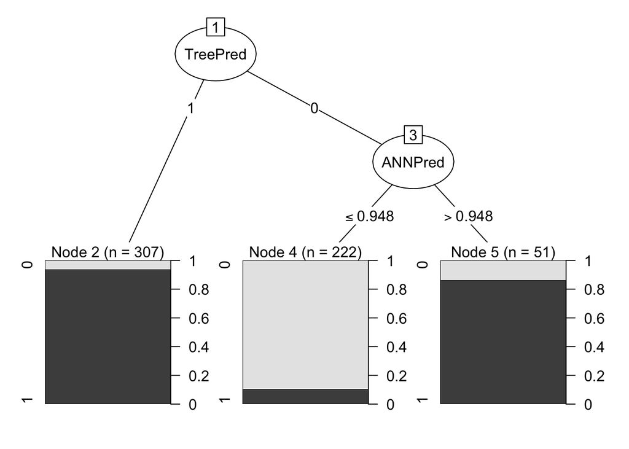

```r
library(C50)
set.seed(12345)
stack_tree <- C5.0(as.factor(Graduated) ~., data = stack_train)

plot(stack_tree)
```

## Evaluating Decision Tree on Stacked Data

```r
stack_tree_pred <- predict(stack_tree, stack_test)

cm<- confusionMatrix(as.factor(stack_tree_pred), as.factor(stack_test$Graduated), positive = "1")
cm
```

```
## Confusion Matrix and Statistics
##
##           Reference
## Prediction  0  1
##          0 43 11
##          1  9 83
##
##                Accuracy : 0.863
##                  95% CI : (0.7964, 0.9143)
##     No Information Rate : 0.6438
##     P-Value [Acc > NIR] : 2.45e-09
##
##                   Kappa : 0.7039
##
##  Mcnemar's Test P-Value : 0.8231
##
##             Sensitivity : 0.8830
##             Specificity : 0.8269
##          Pos Pred Value : 0.9022
##          Neg Pred Value : 0.7963
##              Prevalence : 0.6438
##          Detection Rate : 0.5685
##    Detection Prevalence : 0.6301
##       Balanced Accuracy : 0.8550
##
##        'Positive' Class : 1
##
```

```r
stack_kappa <- cm$overall['Kappa']
stack_accuracy <- cm$overall['Accuracy']
stack_spec <- get_specificity(cm)
```

Stacked Model Performance

- Kappa: 0.703854
- Accuracy: 0.8630137
- Specificity: 0.8269231

Note: You might have noticed that the numbers in the confusion matrix is significantly smaller than our baseline models. This is because we are training the stacked tree model on the testing set of students who have graduated/dropped out in the past. Note that stack_train has 580 rows, and stack_test has 146 rows.

Surprisingly, the stacked model is not the best performing model in regards to Specificity, Kappa, Accuracy score! Below is a summary table on statistical metrics we care about:

```r
data.frame(
  model_name = c("Logistic", "ANN", "Decision Tree", "Random Forest", "Improved Logistic", "Improved ANN", "Improved Decision Tree", "Improved Random Forest", "Stacked Tree"),
  specificity = c(log_spec, ann_spec, dt_spec, rf_spec, log_impr_spec, ann_impr_spec, dt_impr_spec, rf_impr_spec, stack_spec),
  kappa = c(log_kappa, ann_kappa, dt_kappa, rf_kappa, log_impr_kappa, ann_impr_kappa, dt_impr_kappa, rf_impr_kappa, stack_kappa),
  accuracy = c(log_accuracy, ann_accuracy, dt_accuracy, rf_accuracy, log_impr_accuracy, ann_impr_accuracy, dt_impr_accuracy, rf_impr_accuracy, stack_accuracy)
)
```

```
##               model_name specificity     kappa  accuracy
## 1               Logistic   0.8555957 0.7445726 0.8787879
## 2                    ANN   0.8483755 0.7686275 0.8911846
## 3          Decision Tree   0.8194946 0.7857090 0.9008264
## 4          Random Forest   0.8267148 0.7834961 0.8994490
## 5      Improved Logistic   0.8772563 0.7358685 0.8732782
## 6           Improved ANN   0.8700361 0.7243845 0.8677686
## 7 Improved Decision Tree   0.9061372 0.6809529 0.8429752
## 8 Improved Random Forest   0.8808664 0.7362273 0.8732782
## 9           Stacked Tree   0.8269231 0.7038540 0.8630137
```

Since our primary goal is to lower false positive in the predictive model, we will use the Improved Decision Tree model, which has the highest specificity of 0.9061372, to create predictions on currently enrolled students.

# Creating Predictions through Best Performing Model

```r
#Reading in our Enrolled Students
enrolled <- read.csv("cleaned_enrolls.csv")

tree_enroll_pred <- predict(errortree, enrolled)

summary(tree_enroll_pred)
```

```
##   0   1
## 296 498
```

## Adding Prediction Column On Original Data and Subsetting Enrolled Students

```r
allstudents <- read.csv("dataset.csv")
og_enrolled <- subset(allstudents, allstudents$Target == "Enrolled")

# Add predictions to currently enrolled students
og_enrolled$Graduated <- tree_enroll_pred
og_enrolled$Target <- NULL

graduates <- subset(og_enrolled, og_enrolled$Graduated == "1")
graduates$Graduated <- as.numeric(graduates$Graduated)
dropouts <- subset(og_enrolled, og_enrolled$Graduated == "0")
dropouts$Graduated <- as.numeric(dropouts$Graduated)

enrolled$Graduated <- tree_enroll_pred
graduates_cat <- subset(enrolled, enrolled$Graduated == "1")
graduates_cat$Graduated <- as.numeric(graduates_cat$Graduated)
dropouts_cat <- subset(enrolled, enrolled$Graduated == "0")
dropouts_cat$Graduated <- as.numeric(dropouts_cat$Graduated)


# calculate column means for students who are predicted to graduate, and for students who are predicted to drop out
graduates_mean <- colMeans(graduates)
dropout_mean <- colMeans(dropouts)

grad_cat_mean <- colMeans(graduates_cat)
dropout_cat_mean <- colMeans(dropouts_cat)

enrolledmeans <- data.frame(dropout_mean, graduates_mean)
enrolled_cat_means <- data.frame(grad_cat_mean, dropout_cat_mean)
enrolledmeans
```

```
##                                                dropout_mean graduates_mean
## Marital.status                                   1.11824324     1.17269076
## Application.mode                                 7.91216216     6.83734940
## Application.order                                1.51013514     1.69477912
## Course                                           8.71621622    10.33734940
## Daytime.evening.attendance                       0.91554054     0.89959839
## Previous.qualification                           2.87500000     2.17269076
## Nacionality                                      1.38513514     1.26506024
## Mother.s.qualification                          10.62837838    11.60441767
## Father.s.qualification                          14.79729730    15.92168675
## Mother.s.occupation                              7.89527027     7.73895582
## Father.s.occupation                              8.70608108     8.52409639
## Displaced                                        0.53378378     0.55220884
## Educational.special.needs                        0.01013514     0.01606426
## Debtor                                           0.18918919     0.06827309
## Tuition.fees.up.to.date                          0.85810811     1.00000000
## Gender                                           0.55743243     0.28514056
## Scholarship.holder                               0.08445946     0.21084337
## Age.at.enrollment                               22.30067568    22.40963855
## International                                    0.04054054     0.02409639
## Curricular.units.1st.sem..credited.              0.60135135     0.45180723
## Curricular.units.1st.sem..enrolled.              5.39864865     6.30120482
## Curricular.units.1st.sem..evaluations.           8.81418919     9.65461847
## Curricular.units.1st.sem..approved.              3.21621622     4.97389558
## Curricular.units.1st.sem..grade.                 9.27753378    12.22350257
## Curricular.units.1st.sem..without.evaluations.   0.21283784     0.15662651
## Curricular.units.2nd.sem..credited.              0.41554054     0.32530120
## Curricular.units.2nd.sem..enrolled.              5.33783784     6.29518072
## Curricular.units.2nd.sem..evaluations.           9.04391892     9.66867470
## Curricular.units.2nd.sem..approved.              2.57432432     4.93975904
## Curricular.units.2nd.sem..grade.                 9.10066012    12.31604796
## Curricular.units.2nd.sem..without.evaluations.   0.28040541     0.13253012
## Unemployment.rate                               10.75709459    11.57891566
## Inflation.rate                                   1.19324324     1.22269076
## GDP                                              0.28027027    -0.08162651
## Graduated                                        1.00000000     2.00000000
```

```r
enrolled_cat_means
```

```
##                                                grad_cat_mean dropout_cat_mean
## Marital.status2                                  0.070281124      0.057432432
## Marital.statusOthers                             0.032128514      0.020270270
## Application.mode12                               0.164658635      0.131756757
## Application.mode14                               0.084337349      0.111486486
## Application.mode8                                0.202811245      0.195945946
## Application.modeOthers                           0.144578313      0.226351351
## Application.order                                0.086847390      0.063766892
## Course2                                          0.016064257      0.097972973
## Course3                                          0.032128514      0.016891892
## Course4                                          0.050200803      0.040540541
## Course5                                          0.054216867      0.050675676
## Course6                                          0.102409639      0.081081081
## Course7                                          0.026104418      0.172297297
## Course8                                          0.016064257      0.043918919
## Course9                                          0.122489960      0.158783784
## Course10                                         0.054216867      0.050675676
## Course11                                         0.052208835      0.050675676
## Course12                                         0.180722892      0.033783784
## Course13                                         0.024096386      0.016891892
## Course14                                         0.078313253      0.030405405
## Course15                                         0.046184739      0.037162162
## Course16                                         0.072289157      0.047297297
## Course17                                         0.068273092      0.067567568
## Daytime.evening.attendance1                      0.899598394      0.915540541
## Previous.qualification12                         0.016064257      0.016891892
## Previous.qualification14                         0.056224900      0.091216216
## Previous.qualificationOthers                     0.028112450      0.047297297
## Nacionality14                                    0.008032129      0.006756757
## Nacionality9                                     0.000000000      0.003378378
## NacionalityOthers                                0.016064257      0.030405405
## Mother.s.qualification13                         0.214859438      0.233108108
## Mother.s.qualification22                         0.232931727      0.179054054
## Mother.s.qualification23                         0.118473896      0.108108108
## Mother.s.qualification3                          0.124497992      0.131756757
## Mother.s.qualificationOthers                     0.060240964      0.077702703
## Father.s.qualification14                         0.242971888      0.209459459
## Father.s.qualification24                         0.002008032      0.006756757
## Father.s.qualification27                         0.267068273      0.222972973
## Father.s.qualification28                         0.160642570      0.158783784
```

[output cut: 25 more lines]

```
## Curricular.units.1st.sem..enrolled.              0.370659107      0.317567568
## Curricular.units.1st.sem..evaluations.           0.402275770      0.367257883
## Curricular.units.1st.sem..approved.              0.331593039      0.214414414
## Curricular.units.1st.sem..grade.                 0.719029563      0.545737281
## Curricular.units.1st.sem..without.evaluations.   0.019578313      0.026604730
## Curricular.units.2nd.sem..credited.              0.027108434      0.034628378
## Curricular.units.2nd.sem..enrolled.              0.370304748      0.313990461
## Curricular.units.2nd.sem..evaluations.           0.345309811      0.322997104
## Curricular.units.2nd.sem..approved.              0.411646586      0.214527027
## Curricular.units.2nd.sem..grade.                 0.699775452      0.517082962
## Curricular.units.2nd.sem..without.evaluations.   0.016566265      0.035050676
## Unemployment.rate                                0.462664612      0.367104023
## Inflation.rate                                   0.449486836      0.442942943
## GDP                                              0.525544715      0.573351423
## Graduated                                        2.000000000      1.000000000
```

# Final Analysis of Predictions

## Characteristics of Predicted Dropouts

As we ended up using the decision tree model to, one of the best ways we can see what predictors are going into the decision for currently enrolled students is looking at “attribute usage” the tree itself. This shows the percentage of decisions that use a given attribute. From the list below, we can see that the curricular units in the second semester are large predictors. We can also see that students in courses 16 and 4, which translate to Basic Education and Agronomy, are used as attributes around 50% of the time. Father’s qualification 24, which translates to “Unknown” is also used around 60% of the time. Finally, two of our last big predictors that are financial in nature are whether or not a student is a debtor and whether their student loans are up to date.

Attribute Usage:

- 100.00% Curricular.units.2nd.sem..approved.
- 67.60% Tuition.fees.up.to.date1
- 58.47% Father.s.qualification24
- 57.58% Curricular.units.2nd.sem..grade.
- 55.65% Curricular.units.2nd.sem..credited.
- 53.51% Course16
- 49.00% Course4
- 47.31% Debtor1

## Final Implications and Recommendations

We identify the number of curricular units approved in the second semester as well as timely payment of tuition fees to be the key drivers of the student dropout rate. These results are unsurprising that financial pressures such as tuition payment and pre-existing debt would cause students to ultimately dropout. Furthermore, the correlation between curricular units approved and credited in the second semester suggests student inability to properly craft feasible schedules significantly hampers their ability to graduate.

Firstly, we recommend addressing the financial issue through a number of means. Housing occupies a substantial portion of any student’s budget, and providing affordable on or near-campus alternatives will assist in reducing this expense. Additionally, we also endorse a form of rolling financial in the form of scholarships or work-study opportunities that are available throughout students’ expected four-year stay at the university. This will mitigate front loading financial aid to incoming students in their first year and allow for a more dynamic allocation of resources as needed. Each of these suggestions require a targeted approach that pinpoints those most in financial need. Hence, a vetting process of analyzing student income and wealth is necessary. Particularly, in the modern era, what composes “income” and “wealth” is constantly shifting; therefore, careful consideration of factors such as realized and unrealized income must be taken into consideration to reduce the risk of providing aid to those not realistically qualified as financially distressed.

Finally, the school can look more generally into the average of these characteristics of these students. They can create two profiles, and if they notice that a student is becoming increasingly like their predicted dropout student, they can step in to offer them assistance

These recommendations provide a preliminary round of remedies to deeply systemic issues. Not only to we advocate implementing these measures, we endorse constant and consistent monitoring of their effects to more accurately target students with the highest probably to drop out yet be retained. This will allow for more effective resource allocation in optimizing student retention among and providing the admissions office with the necessary quantitative data to initiate the student transfer process. As such, this strategy furthers the Polytechnic Institute of Portalegre ability to achieve its goals of maximizing human capital, and providing its domestic economy with a more capable labor force.